# Competition Assignment

Florence Lourdes

2023-09-27

```r
#install.packages("tidyverse")
#install.packages("corrr")
#install.packages("ranger")
#install.packages("yardstick")
#install.packages("tidytext")
#install.packages("ggplot2")
#install.packages(c("tm", "slam"))
library(yardstick)
library(dplyr)
library(ggplot2)
library(corrr)
library(tidyverse)
library(tidymodels)
library(kableExtra)
library(patchwork)
library(ggplot2)
library(ranger)
library(tidytext)
library(tm)
library(slam)
data <- read_csv("C:/MAT434/data.csv")
comp <- read_csv("C:/MAT434/comp.csv")
```

# Head of Data

The following table shows the top 6 rows of the data

```r
data %>%
  head()
```

```
## # A tibble: 6 × 16
##      id city   description       homeType latitude longitude garageSpaces hasSpa
##   <dbl> <chr>  <chr>             <chr>       <dbl>     <dbl>        <dbl> <lgl>
## 1     1 austin "7300 Annette Cv… Single …     30.3     -97.6            1 FALSE
## 2     2 austin "Extravagant and… Single …     30.3     -97.8            2 TRUE
## 3     3 austin "HIGH RENTABLE A… Multipl…     30.3     -97.7            1 FALSE
## 4     4 austin "Great house in … Single …     30.3     -97.7            0 FALSE
## 5     5 austin "FOR SALE BY OWN… Single …     30.4     -97.9            0 FALSE
## 6     6 austin "Under market pr… Condo        30.4     -97.7            0 FALSE
## # ℹ 8 more variables: yearBuilt <dbl>, numOfPatioAndPorchFeatures <dbl>,
## #   lotSizeSqFt <dbl>, avgSchoolRating <dbl>, MedianStudentsPerTeacher <dbl>,
## #   numOfBathrooms <dbl>, numOfBedrooms <dbl>, priceRange <chr>
```

# Set a seed for reproducibility

Setting a seed make sure that we get the same results for randomization

```r
set.seed(123)
```

# Split data into training and test sets

Splitting data into a training and test sets with a 8 to 2 ratio and marking price range as prediction target

```r
split_data <- initial_split(data, prop = 0.8, strata = priceRange)  # Adjust ratio and strata as needed
```

# Extract the training and test sets

Extracting the data from each training and test sets. These patterns include outliers and features of the data that might be unexpected. EDA is an important first step in any data analysis

```r
train_data <- training(split_data)
test_data <- testing(split_data)
```

# Build cross-validation folds

K-fold cross-validation is a technique for evaluating predictive models. The dataset is divided into k subsets or folds. The model is trained and evaluated k times, using a different fold as the validation set each time. Performance metrics from each fold are averaged to estimate the model’s generalization performance.

```r
set.seed(456)
train_folds <- vfold_cv(train_data, v = 10)
```

# Exploratory Data Analysis (EDA)

EDA is an analysis approach that identifies general patterns in the data. These patterns include outliers and features of the data that might be unexpected. EDA is an important first step in any data analysis.

```r
# Summary statistics
summary(train_data)
```

```
##        id           city           description          homeType
##  Min.   :   1   Length:5996        Length:5996        Length:5996
##  1st Qu.:1861   Class :character   Class :character   Class :character
##  Median :3742   Mode  :character   Mode  :character   Mode  :character
##  Mean   :3748
##  3rd Qu.:5633
##  Max.   :7498
##     latitude       longitude       garageSpaces      hasSpa
##  Min.   :30.09   Min.   :-98.02   Min.   : 0.000   Mode :logical
##  1st Qu.:30.20   1st Qu.:-97.84   1st Qu.: 0.000   FALSE:5525
##  Median :30.28   Median :-97.77   Median : 1.000   TRUE :471
##  Mean   :30.29   Mean   :-97.78   Mean   : 1.224
##  3rd Qu.:30.37   3rd Qu.:-97.72   3rd Qu.: 2.000
##  Max.   :30.52   Max.   :-97.57   Max.   :22.000
##    yearBuilt    numOfPatioAndPorchFeatures  lotSizeSqFt       avgSchoolRating
##  Min.   :1907   Min.   :0.0000             Min.   :     100   Min.   :2.333
##  1st Qu.:1975   1st Qu.:0.0000             1st Qu.:    6534   1st Qu.:4.000
##  Median :1993   Median :0.0000             Median :    8189   Median :5.667
##  Mean   :1989   Mean   :0.6583             Mean   :   23361   Mean   :5.752
##  3rd Qu.:2006   3rd Qu.:1.0000             3rd Qu.:   10890   3rd Qu.:7.000
##  Max.   :2020   Max.   :6.0000             Max.   :34154525   Max.   :9.500
##  MedianStudentsPerTeacher numOfBathrooms   numOfBedrooms     priceRange
##  Min.   :10.00            Min.   : 1.000   Min.   : 1.000   Length:5996
##  1st Qu.:14.00            1st Qu.: 2.000   1st Qu.: 3.000   Class :character
##  Median :15.00            Median : 3.000   Median : 3.000   Mode  :character
##  Mean   :14.86            Mean   : 2.696   Mean   : 3.439
##  3rd Qu.:16.00            3rd Qu.: 3.000   3rd Qu.: 4.000
##  Max.   :19.00            Max.   :10.000   Max.   :10.000
```

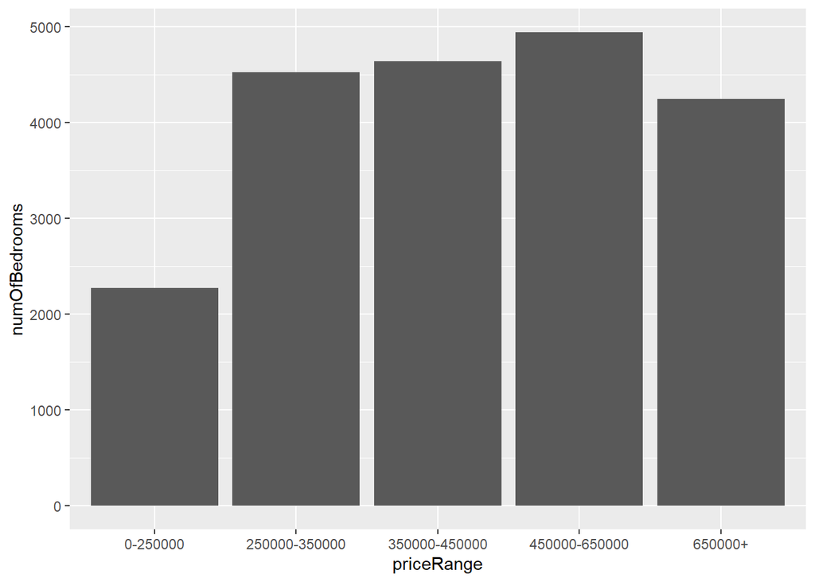

```r
# Bar plots for categorical variables
ggplot(train_data, aes(x = priceRange, y=numOfBedrooms)) +
  geom_bar(stat = "identity")
```

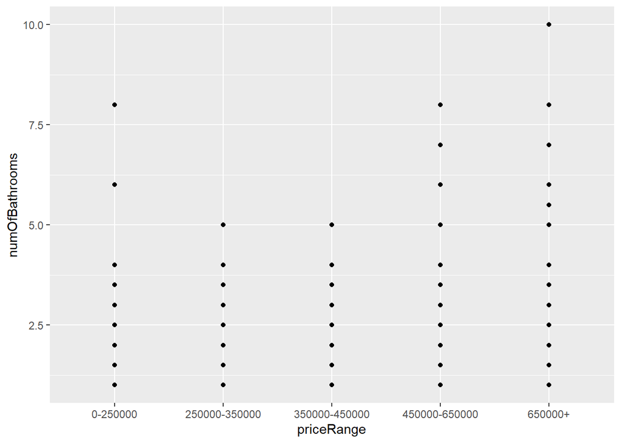

```r
# Scatterplots for relationships
ggplot(train_data, aes(x=priceRange, y=numOfBathrooms)) +
    geom_point()
```

```r
# Correlation matrix
data_cor <- train_data %>%
  select(numOfBedrooms, lotSizeSqFt, priceRange) %>%
  correlate()
```

```
## Non-numeric variables removed from input: `priceRange`
## Correlation computed with
## • Method: 'pearson'
## • Missing treated using: 'pairwise.complete.obs'
```

The next chunk of code utilizes text based extraction to determine the top 20 words most commonly found in the description.

```r
# Tokenize the description feature
data_text <- data %>%
  select(id, description, priceRange) %>%
  unnest_tokens(word, description) %>%
  anti_join(stop_words)
```

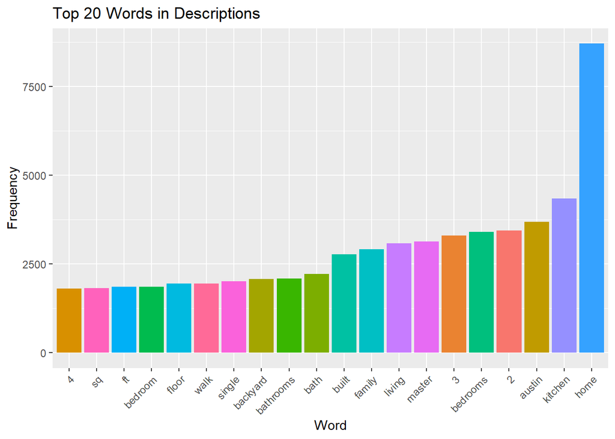

```r
# Count word frequencies
word_freq <- data_text %>%
  count(word, sort = TRUE)

# Visualize top words
top_words_plot <- word_freq %>%
  top_n(20) %>%
  ggplot(aes(x = reorder(word, n), y = n, fill = word)) +
  geom_col(show.legend = FALSE) +
  labs(title = "Top 20 Words in Descriptions", x = "Word", y = "Frequency") +
  theme(axis.text.x = element_text(angle = 45, hjust = 1))
# Print the plot
print(top_words_plot)
```

Now let’s dive deeper into text based extraction. We will be filtering out some of the commonly found words and group the resulting words’ frequency based on price range.

```r
# Assuming this is part of your existing code
train_data_text <- training(split_data)

# Tokenize the text and remove stop words
word_tokens <- train_data_text %>%
  unnest_tokens(word, description) %>%
  anti_join(stop_words) %>%
  filter(!(word %in% c("home", "bedrooms", "bedroom", "bathrooms", "kitchen", "family", "living", "master", "single", "backyard", "austin", "tx", "ft", "built", "bath", "sq", "dining"))) %>%
  filter(!str_detect(word, "\\d+"))
# Count word frequencies
word_freq <- word_tokens %>%
  group_by(priceRange) %>%
  count(word) %>%
  top_n(15) %>%
  ungroup() %>%
  mutate(priceRange = as.factor(priceRange),
         word = reorder_within(word, n, priceRange))
```

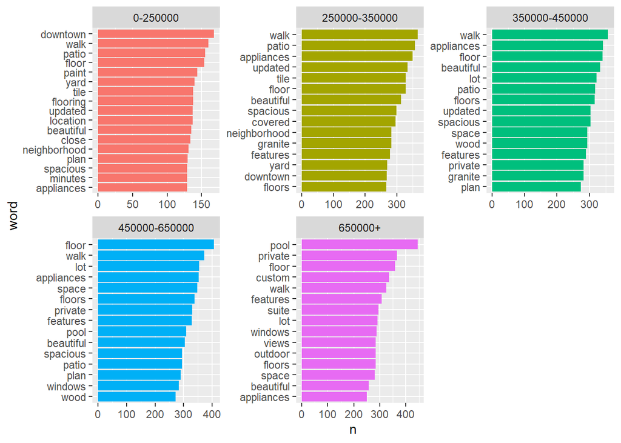

```r
# Create the plot
top_words_plot <- word_freq %>%
  ggplot() +
  geom_col(aes(x = word, y = n, fill = priceRange), show.legend = FALSE) +
  scale_x_reordered() +
  coord_flip() +
  facet_wrap(~priceRange, scales = "free")

# Print the plot
print(top_words_plot)
```

# Model Construction and Interpretation

In the following code, we will be using two training models: nearest neighbor and decision tree.The steps are to make a workflow, evaluate, and print the result.

```r
# KNN workflow
knn_spec <- nearest_neighbor() %>%
  set_engine("kknn") %>%
  set_mode("classification")

knn_rec <- recipe(priceRange ~ numOfBedrooms + numOfBathrooms + lotSizeSqFt, data = train_data) %>%
  step_impute_median(all_numeric_predictors()) %>%
  step_unknown(all_nominal_predictors()) %>%
  step_dummy(all_nominal_predictors())

knn_wf <- workflow() %>%
  add_model(knn_spec) %>%
  add_recipe(knn_rec)

# Decision tree workflow
dt_spec <- decision_tree() %>%
  set_engine("rpart") %>%
  set_mode("classification")

dt_rec <- recipe(priceRange ~ numOfBedrooms + numOfBathrooms + lotSizeSqFt, data = train_data) %>%
  step_impute_median(all_numeric_predictors()) %>%
  step_unknown(all_nominal_predictors()) %>%
  step_dummy(all_nominal_predictors())

dt_wf <- workflow() %>%
  add_model(dt_spec) %>%
  add_recipe(dt_rec)

# Evaluate workflows
knn_cv_results <- knn_wf %>%
  fit_resamples(train_folds)

dt_cv_results <- dt_wf %>%
  fit_resamples(train_folds)
```

Here is the KNN result

```r
# KNN result
knn_cv_results %>%
  collect_metrics()
```

```
## # A tibble: 2 × 6
##   .metric  .estimator  mean     n std_err .config
##   <chr>    <chr>      <dbl> <int>   <dbl> <chr>
## 1 accuracy multiclass 0.329    10 0.00444 Preprocessor1_Model1
## 2 roc_auc  hand_till  0.636    10 0.00396 Preprocessor1_Model1
```

Here is the decision tree result

```r
# DT result
dt_cv_results %>%
  collect_metrics()
```

```
## # A tibble: 2 × 6
##   .metric  .estimator  mean     n std_err .config
##   <chr>    <chr>      <dbl> <int>   <dbl> <chr>
## 1 accuracy multiclass 0.372    10 0.00543 Preprocessor1_Model1
## 2 roc_auc  hand_till  0.680    10 0.00346 Preprocessor1_Model1
```

Result Summary: the decision tree model has higher accuracy values

Next, we will be using hyperparameter tuning. Hyperparameter tuning allows data scientists to tweak model performance for optimal results. This process is an essential part of machine learning, and choosing appropriate hyperparameter values is crucial for success.

We will start off by setting the grid parameter of tune_grid() to a number which will create a “space filling” grid containing that number of hyperparameter combinations. These are essentially tibbles (data frames) of options for each hyperparameter.

```r
# Grid
grid_neighbors <- tibble(
  "neighbors" = c(1, 3, 5, 7, 11, 15, 21, 41)
  )

grid_depth <- tibble(
  "tree_depth" = c(2, 3, 4, 5, 8, 10, 12, 15, 20)
  )
```

The next step is to re-create the model workflows, setting the relevant hyperparameters to tune(). Then we’ll pipe these workflows into tune_grid() and read the results.

```r
# KNN workflow
knn_spec <- nearest_neighbor(neighbors = tune()) %>%
  set_engine("kknn") %>%
  set_mode("classification")

knn_rec <- recipe(priceRange ~ numOfBedrooms + numOfBathrooms + lotSizeSqFt , data = train_data) %>%
  step_impute_median(all_numeric_predictors()) %>%
  step_unknown(all_nominal_predictors()) %>%
  step_dummy(all_nominal_predictors())

knn_wf <- workflow() %>%
  add_model(knn_spec) %>%
  add_recipe(knn_rec)

# DT workflow
dt_spec <- decision_tree(tree_depth = tune()) %>%
  set_engine("rpart") %>%
  set_mode("classification")

dt_rec <- recipe(priceRange ~ numOfBedrooms + numOfBathrooms + lotSizeSqFt, data = train_data) %>%
  step_impute_median(all_numeric_predictors()) %>%
  step_unknown(all_nominal_predictors()) %>%
  step_dummy(all_nominal_predictors())

dt_wf <- workflow() %>%
  add_model(dt_spec) %>%
  add_recipe(dt_rec)

# Hyperparameter tune
knn_tune_results <- knn_wf %>%
  tune_grid(
    grid = grid_neighbors,
    resamples = train_folds
  )

dt_tune_results <- dt_wf %>%
  tune_grid(
    grid = grid_depth,
    resamples = train_folds
  )
```

Here is the tuned nearest neighbor result:

```r
# KNN result
knn_tune_results %>%
  collect_metrics() %>%
  filter(.metric == "accuracy") %>%
  select(neighbors, mean, std_err) %>%
  arrange(-mean)
```

```
## # A tibble: 8 × 3
##   neighbors  mean std_err
##       <dbl> <dbl>   <dbl>
## 1        41 0.383 0.00435
## 2        21 0.379 0.00416
## 3        15 0.373 0.00564
## 4        11 0.364 0.00631
## 5         7 0.349 0.00527
## 6         5 0.329 0.00444
## 7         1 0.286 0.00482
## 8         3 0.276 0.00348
```

Here is the decission tree result:

```r
# DT results
dt_tune_results %>%
  collect_metrics() %>%
  filter(.metric == "accuracy") %>%
  select(tree_depth, mean, std_err) %>%
  arrange(-mean)
```

```
## # A tibble: 9 × 3
##   tree_depth  mean std_err
##        <dbl> <dbl>   <dbl>
## 1          3 0.372 0.00543
## 2          4 0.372 0.00543
## 3          5 0.372 0.00543
## 4          8 0.372 0.00543
## 5         10 0.372 0.00543
## 6         12 0.372 0.00543
## 7         15 0.372 0.00543
## 8         20 0.372 0.00543
## 9          2 0.353 0.00837
```

After deciding on a model with the highest accuracy result, we will be fitting the model to do predictions on the competition data set. The predictions will then be exported as a csv file for submission.

```r
# Setting the grid with the highest accuracy
knn_spec <- nearest_neighbor(neighbors = 41) %>%
  set_engine("kknn") %>%
  set_mode("classification")

knn_rec <- recipe(priceRange ~ numOfBedrooms + numOfBathrooms + lotSizeSqFt, data = train_data) %>%
  step_impute_median(all_numeric_predictors()) %>%
  step_unknown(all_nominal_predictors()) %>%
  step_dummy(all_nominal_predictors())

knn_wf <- workflow() %>%
  add_model(knn_spec) %>%
  add_recipe(knn_rec)

# Fitting workflow
knn_fit <- knn_wf %>%
  fit(data)

# Enter competition data
knn_fit %>%
  augment(comp)
```

```
## # A tibble: 2,502 × 21
##       id city   description      homeType latitude longitude garageSpaces hasSpa
##    <dbl> <chr>  <chr>            <chr>       <dbl>     <dbl>        <dbl> <lgl>
##  1     1 austin "Pride in owner… Single …     30.4     -97.7            2 FALSE
##  2     2 austin "Enjoy endless … Single …     30.4     -97.8            0 FALSE
##  3     3 austin "Awesome opport… Single …     30.2     -97.8            4 TRUE
##  4     4 austin "Gorgeous open … Single …     30.4     -97.6            2 FALSE
##  5     5 austin "Two miles from… Single …     30.3     -97.7            0 FALSE
##  6     6 austin "4602 Sherwyn D… Single …     30.3     -97.7            0 FALSE
##  7     7 austin "Contemporary l… Condo        30.3     -97.7            1 FALSE
##  8     8 austin "Investment opp… Single …     30.2     -97.8            0 FALSE
##  9     9 austin "Amazing South … Single …     30.2     -97.8            2 FALSE
## 10    10 austin "5217 Bluestar … Single …     30.2     -97.9            0 FALSE
## # ℹ 2,492 more rows
## # ℹ 13 more variables: yearBuilt <dbl>, numOfPatioAndPorchFeatures <dbl>,
## #   lotSizeSqFt <dbl>, avgSchoolRating <dbl>, MedianStudentsPerTeacher <dbl>,
## #   numOfBathrooms <dbl>, numOfBedrooms <dbl>, .pred_class <fct>,
## #   `.pred_0-250000` <dbl>, `.pred_250000-350000` <dbl>,
## #   `.pred_350000-450000` <dbl>, `.pred_450000-650000` <dbl>,
## #   `.pred_650000+` <dbl>
```

```r
# Select and rename columns
submission_df <- knn_fit %>%
  augment(comp) %>%
  select(id, contains(".pred"), -.pred_class) %>%
  rename(prob_A = ".pred_0-250000",
         prob_B = ".pred_250000-350000",
         prob_C = ".pred_350000-450000",
         prob_D = ".pred_450000-650000",
         prob_E = ".pred_650000+")

# Export
write.csv(submission_df, "ZillowSubmission.csv", row.names = FALSE)
```

The next step is to explore another model to hopefully get a higher accuracy. The model that we are going to use now is random forest. A random forest is a form of bootstrap aggregation where we construct a decision tree model on each of the bootstrapped training sets. Rather than just constructing a decision tree though, we allow each tree access to only a random subset of predictors each time it makes a split. Since the trees are provided random access to the predictors, our trees won’t all look alike. This means that the decision trees in our random forest ensemble won’t make the same errors and the ensemble can benefit from the wisdom of the crowd.

```r
# Define random forest
rf_spec <- rand_forest() %>%
  set_engine("ranger", importance = "impurity") %>%
  set_mode("classification")

#Set recipe
rf_rec <- recipe(priceRange ~ numOfBedrooms + numOfBathrooms + lotSizeSqFt, data = train_data) %>%
  step_impute_knn(all_predictors()) %>%
  step_dummy(all_nominal_predictors())

# Create workflow
rf_wf <- workflow() %>%
  add_model(rf_spec) %>%
  add_recipe(rf_rec)

# Fit model
rf_fit <- rf_wf %>%
  fit(data)

rf_fit %>%
  extract_fit_engine() %>%
  ranger::treeInfo(tree = 1)
```

[output not shown]

[output cut: 627 more lines]

```r
# Evaluate workflows
rf_cv_results <- rf_wf %>%
  fit_resamples(train_folds)
```

```r
# Random Forest result
rf_cv_results %>%
  collect_metrics()
```

```
## # A tibble: 2 × 6
##   .metric  .estimator  mean     n std_err .config
##   <chr>    <chr>      <dbl> <int>   <dbl> <chr>
## 1 accuracy multiclass 0.401    10 0.00697 Preprocessor1_Model1
## 2 roc_auc  hand_till  0.731    10 0.00329 Preprocessor1_Model1
```

```r
# Specify the random forest model with hyperparameter grid
rf_spec <- rand_forest(trees = tune(), mtry = tune()) %>%
  set_engine("ranger", importance = "impurity") %>%
  set_mode("classification")

# Set recipe
rf_rec <- recipe(priceRange ~ numOfBedrooms + numOfBathrooms + lotSizeSqFt, data = train_data) %>%
  step_impute_knn(all_predictors()) %>%
  step_dummy(all_nominal_predictors())

# Create the workflow with the model specification and recipe
rf_wf <- workflow() %>%
  add_model(rf_spec) %>%
  add_recipe(rf_rec)

# Perform hyperparameter tuning
rf_tune_results <- rf_wf %>%
  tune_grid(
    resamples = rsample::bootstraps(train_data, times = 5),
    grid = expand.grid(trees = c(50, 100, 150, 200), mtry = c(2, 4, 6, 8))
  )
```

```
## → A | warning: 4 columns were requested but there were 3 predictors in the data. 3 will be used.
```

[output not shown]

[output cut: 75 more lines]

[output not shown]

```r
# Print the results of hyperparameter tuning
collect_metrics(rf_tune_results)
```

```
## # A tibble: 32 × 8
##     mtry trees .metric  .estimator  mean     n std_err .config
##    <dbl> <dbl> <chr>    <chr>      <dbl> <int>   <dbl> <chr>
##  1     2    50 accuracy multiclass 0.380     5 0.00312 Preprocessor1_Model01
##  2     2    50 roc_auc  hand_till  0.708     5 0.00162 Preprocessor1_Model01
##  3     2   100 accuracy multiclass 0.381     5 0.00354 Preprocessor1_Model02
##  4     2   100 roc_auc  hand_till  0.708     5 0.00138 Preprocessor1_Model02
##  5     2   150 accuracy multiclass 0.378     5 0.00227 Preprocessor1_Model03
##  6     2   150 roc_auc  hand_till  0.707     5 0.00128 Preprocessor1_Model03
##  7     2   200 accuracy multiclass 0.379     5 0.00318 Preprocessor1_Model04
##  8     2   200 roc_auc  hand_till  0.708     5 0.00142 Preprocessor1_Model04
##  9     4    50 accuracy multiclass 0.355     5 0.00285 Preprocessor1_Model05
## 10     4    50 roc_auc  hand_till  0.677     5 0.00219 Preprocessor1_Model05
## # ℹ 22 more rows
```

Unfortunately, none of the grids produced an accuracy higher than the untuned random forest. The hyperparameter grid used in the tuning process may not include values that improve the model’s performance. It’s essential to carefully choose the range and values for hyperparameters. Expanding the search space or consider different values for mtry and trees may give a higher accuracy value but the downside is it can take a very long time to run. For now, let’s fit the untuned random forest model.

```r
# Extract the best model
rf_spec <- rand_forest() %>%
  set_engine("ranger", importance = "impurity") %>%
  set_mode("classification")

rf_rec <- recipe(priceRange ~ numOfBedrooms + numOfBathrooms + lotSizeSqFt, data = train_data) %>%
  step_impute_knn(all_predictors()) %>%
  step_dummy(all_nominal_predictors())

# Create workflow
rf_wf <- workflow() %>%
  add_model(rf_spec) %>%
  add_recipe(rf_rec)

# Fit model
rf_fit <- rf_wf %>%
  fit(data)

# Enter competition data
rf_fit %>%
  augment(comp)
```

```
## # A tibble: 2,502 × 21
##       id city   description      homeType latitude longitude garageSpaces hasSpa
##    <dbl> <chr>  <chr>            <chr>       <dbl>     <dbl>        <dbl> <lgl>
##  1     1 austin "Pride in owner… Single …     30.4     -97.7            2 FALSE
##  2     2 austin "Enjoy endless … Single …     30.4     -97.8            0 FALSE
##  3     3 austin "Awesome opport… Single …     30.2     -97.8            4 TRUE
##  4     4 austin "Gorgeous open … Single …     30.4     -97.6            2 FALSE
##  5     5 austin "Two miles from… Single …     30.3     -97.7            0 FALSE
##  6     6 austin "4602 Sherwyn D… Single …     30.3     -97.7            0 FALSE
##  7     7 austin "Contemporary l… Condo        30.3     -97.7            1 FALSE
##  8     8 austin "Investment opp… Single …     30.2     -97.8            0 FALSE
##  9     9 austin "Amazing South … Single …     30.2     -97.8            2 FALSE
## 10    10 austin "5217 Bluestar … Single …     30.2     -97.9            0 FALSE
## # ℹ 2,492 more rows
## # ℹ 13 more variables: yearBuilt <dbl>, numOfPatioAndPorchFeatures <dbl>,
## #   lotSizeSqFt <dbl>, avgSchoolRating <dbl>, MedianStudentsPerTeacher <dbl>,
## #   numOfBathrooms <dbl>, numOfBedrooms <dbl>, .pred_class <fct>,
## #   `.pred_0-250000` <dbl>, `.pred_250000-350000` <dbl>,
## #   `.pred_350000-450000` <dbl>, `.pred_450000-650000` <dbl>,
## #   `.pred_650000+` <dbl>
```

```r
# Select and rename columns
submission_df <- rf_fit %>%
  augment(comp) %>%
  select(id, contains(".pred"), -.pred_class) %>%
  rename(prob_A = ".pred_0-250000",
         prob_B = ".pred_250000-350000",
         prob_C = ".pred_350000-450000",
         prob_D = ".pred_450000-650000",
         prob_E = ".pred_650000+")

# Export
write.csv(submission_df, "ZillowSubmission.csv", row.names = FALSE)
```